# Tidyverse Vignette

Devanshu Mehrotra

## 1. Purpose of this project

To create a programming sample vignette that demonstrates how to use one or more of the capabilities of selected TidyVerse packages using a dataset selected either from Kaggle or Fivethirtyeight.

## 2. About Tidyverse

[figure not shown]

#### Tidyverse is a collection of packages designed for datascience applications. Currently it consists of the following packages:

1. *ggplot2* - for creating graphics
2. *dplyr* - for data manipulation
3. *tidyr* - to get data into a consistent and ‘tidy’ format
4. *readr*- to read rectangular data
5. *purr* - tools for working with functions and vectors
6. *tibble* - modified data framing tool
7. *stringr* - for working with strings
8. *forcats* - tools to solve commong problemsn with factors.

For more information please visit [Tidyverse](https://www.tidyverse.org)

## 3. Dataset

The dataset selected for this vignette details defense spending by country from 1960 through 2018. This data was sourced from kaggle and can be found [here](https://www.kaggle.com/nitinsss/military-expenditure-of-countries-19602019). This data was first published by the World Bank and a more expanded dataset with relevant infromation can be found at the [World Bank Website](https://data.worldbank.org/indicator/MS.MIL.XPND.CD)

## 4. Readr (read_csv)

Since this data can be considered rectangular and is in a csv format, we are going to demonstrate the capabilities of the read_csv function from the readr package.

As detailed in the [documentation for read_csv()](https://readr.tidyverse.org/reference/read_delim.html), the `read_csv()` function is a special case of `read_delim()` which is useful for reading common types of flat file data which is comma separated values. The syntax and a few limited arguments are as follows:

`read_csv(file, col_names = TRUE, col_types = NULL, skip = 0, n_max = Inf, guess_max = min(1000,n_max), skip_empty_rows = TRUE)`

where:

- file - path to a file, a connection, or literal data
- col_names - If TRUE, the first row of the input will be used as the column names, If FALSE, column names will be generated automatically: X1, X2, X3 etc.
- col_types - If NULL, all column types will be imputed from the first 1000 rows on the input.If a column specification created by cols(), it must contain one column specification for each column.
- skip - Number of lines to skip before reading data.
- n_max - Maximum number of records to read.
- skip_empty_rows - Should blank rows be ignored

```r
#importing the tidyverse library
library(tidyverse)
#creating a dataframe called military by importing the Military Expenditure data

military <- read_csv('Military Expenditure.csv',col_names = TRUE, col_types = NULL ,skip = 0 , n_max =Inf, skip_empty_rows = TRUE)
# reviewing the first 5 lines of the resulting dataframe
head(military)
```

```
## # A tibble: 6 x 63
##   Name  Code  Type  `Indicator Name` `1960` `1961`  `1962`  `1963`  `1964`
##   <chr> <chr> <chr> <chr>             <dbl>  <dbl>   <dbl>   <dbl>   <dbl>
## 1 Aruba ABW   Coun… Military expend…     NA     NA NA      NA      NA
## 2 Afgh… AFG   Coun… Military expend…     NA     NA NA      NA      NA
## 3 Ango… AGO   Coun… Military expend…     NA     NA NA      NA      NA
## 4 Alba… ALB   Coun… Military expend…     NA     NA NA      NA      NA
## 5 Ando… AND   Coun… Military expend…     NA     NA NA      NA      NA
## 6 Arab… ARB   Regi… Military expend…     NA     NA  8.33e8  9.16e8  1.23e9
## # … with 54 more variables: `1965` <dbl>, `1966` <dbl>, `1967` <dbl>,
## #   `1968` <dbl>, `1969` <dbl>, `1970` <dbl>, `1971` <dbl>, `1972` <dbl>,
## #   `1973` <dbl>, `1974` <dbl>, `1975` <dbl>, `1976` <dbl>, `1977` <dbl>,
## #   `1978` <dbl>, `1979` <dbl>, `1980` <dbl>, `1981` <dbl>, `1982` <dbl>,
## #   `1983` <dbl>, `1984` <dbl>, `1985` <dbl>, `1986` <dbl>, `1987` <dbl>,
## #   `1988` <dbl>, `1989` <dbl>, `1990` <dbl>, `1991` <dbl>, `1992` <dbl>,
## #   `1993` <dbl>, `1994` <dbl>, `1995` <dbl>, `1996` <dbl>, `1997` <dbl>,
## #   `1998` <dbl>, `1999` <dbl>, `2000` <dbl>, `2001` <dbl>, `2002` <dbl>,
## #   `2003` <dbl>, `2004` <dbl>, `2005` <dbl>, `2006` <dbl>, `2007` <dbl>,
## #   `2008` <dbl>, `2009` <dbl>, `2010` <dbl>, `2011` <dbl>, `2012` <dbl>,
## #   `2013` <dbl>, `2014` <dbl>, `2015` <dbl>, `2016` <dbl>, `2017` <dbl>,
## #   `2018` <dbl>
```

## 5. Tidyr (pivot_longer)

According to the tidyverse webset, the goal of of tidyr is to create ‘tidy data’ where:

1. Every column is variable.
2. Every row is an observation..
3. Every cell is a single value.

When reviewing the dataframe created above, we note that the original dataset is in a ‘wide’ format. In order to effectively work this dataset we would have to tansform this dataset into long form. This is where the pivotting functions of the tidyr package comes into play. The specific pivotting fuction we will be using is pivot_longer() which is replacing gather(). Note that the pivot_longer() still in development hence this exercise uses the devtools version of tidyverse.

As detailed in the [documentation for pivot_longer()](https://tidyr.tidyverse.org/reference/pivot_longer.html), the `pivot_longer()` function " ‘lengthens’ data, increasing the number of rows and decreasing the number of columns. The syntax and a few limited arguments are as follows:

``pivot_longer(data, cols, names_to = "name",values_drop_na = FALSE`

where:

- data - data frame to pivot.
- cols - columns to pivot into longer format
- names_to - string specifying the name of the column to create
- values_to - name of the column to create from the data stored in cell values
- values_drop_na - If TRUE, will drop rows that contain only NAs.

```r
# creating a datframe called mil_long by pivoting all of the columns that contain years using the regex matches('^[0-9]')
mil_long <- pivot_longer(military, cols=matches('^[0-9]'),names_to="year", values_to='expenditure')

# reviewing the first 5 lines of the dataframe mil_long
head(mil_long)
```

```
## # A tibble: 6 x 6
##   Name  Code  Type    `Indicator Name`                   year  expenditure
##   <chr> <chr> <chr>   <chr>                              <chr>       <dbl>
## 1 Aruba ABW   Country Military expenditure (current USD) 1960           NA
## 2 Aruba ABW   Country Military expenditure (current USD) 1961           NA
## 3 Aruba ABW   Country Military expenditure (current USD) 1962           NA
## 4 Aruba ABW   Country Military expenditure (current USD) 1963           NA
## 5 Aruba ABW   Country Military expenditure (current USD) 1964           NA
## 6 Aruba ABW   Country Military expenditure (current USD) 1965           NA
```

## 6. dplyr (mutate, filter)

The [dplyr](https://dplyr.tidyverse.org) library is considered to be the “grammar of data manipulation”. The five ‘verbs’ of manipulating data with dplyr are:

1. mutate() - adds new variables that are functions of existing variables
2. select() - picks variables based on their names.
3. filter() - picks cases based on their values.
4. summarise() - reduces multiple values down to a single summary.
5. arrange() - changes the ordering of the rows.

For our purposes of this exercise we are going to use the mutate and filter functions:

1. `mutate()` - Currently the expenditure column is in dollars. For convenience we will create a new column to indicate expenditure in billions. We will use the mutate() function in dplyr to achieve this. This functions lets us add new variables to the dataframe while preserving the old ones.

The syntax for mutate is:

`mutate(data, calculation )`

```r
mil_long <- mutate(mil_long, spend_in_billions = expenditure/1000000000)
```

The filter function syntax is as follows:

`filter(.data, ogical condition, .preserve = FALSE)`

where:

- data - data table
- logical condition - Multiple conditions are combined with &. Only rows where the condition evaluates to TRUE are kept.
- preserve- when FALSE, the grouping structure is recalculated based on the resulting data, otherwise it is kept as is.

```r
 mil_short<- filter(mil_long, Code %in% c('USA', 'EUU', 'IND'))
```

## 7. ggplot2 (geom_line)

Finally we are going to plot the three expenditures on the same graph using the ggplot2 package. The steps to create a line chart using ggplot is as follows:

#### Step 1:

- `ggplot()` initialize a ggplot object which declares input data frame for a graphic and sets aesthetics intended to be common throughout all subsequent layers. Syntax for creating a ggplot object is

`ggplot(data = NULL, mapping = aes(), ...)`

Where: - data- dataset to used for plotting.

- mapping - list of aesthetic mappings to use for plotting

#### Step 2

`geom_line()` connects all the observations within the data frame. Note in order to plot lines we have to specify the number of groups within a dataframe , or the column whose discrete values will determine the number of groups. In the example below the column which contrains country codes (‘Code’) will determine grouping since each line is for a single value of ‘Code’

#### Step 3

Other arguments to determine the overall look of the visualiation

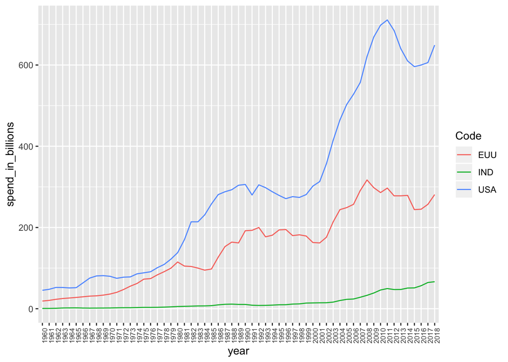

```r
# ggplot- defining x and y axis along with grouping criteria
# geom_line- specifiying that each 'Code' should get its own color
# theme- reducing the size of the x axis label and rotating it 90 degrees to avoid overlapping labels)
ggplot(mil_short, aes(x=year,y=spend_in_billions, group =Code))  + geom_line(aes(color=Code)) + theme(axis.text.x = element_text(size = 7, angle = 90, hjust = 1))
```